# Student Activity 4 — Feedback and Worked Solution

A Course on Data Visualization · Commentary on the Group Activity

Livio Finos, University of Padova

# 1 How to use this solution

**Instructor copy — release after the group activity.** Distribute the student handout and CSV first. Keep this solution and the data-generation script separate until students have submitted their interpretation. For the initial planning discussion, reveal only Part 1 of the handout.

This document provides one worked approach and general feedback. It is not an assessment of individual submissions. Compare your original study proposal with the choices below and explain any revisions. Other well-justified designs and clear visualizations are acceptable.

# 2 Part 1: A reasonable study proposal

The descriptive question is whether children with larger shoe sizes have higher scores on a common reading assessment. A separate question asks whether this relationship remains among children in the same school year. Neither question is the causal effect of changing a child’s shoes.

Define the target population, for example children in Years 1, 3, and 5 in a specified school district. A feasible proposal would sample children within each year, using a sampling frame rather than only volunteers who find reading easy. Obtain school and guardian permission and the child’s assent, and store anonymous identifiers. Standardise the sizing procedure and use the same reading assessment and instructions for every child. One row represents one child measured once.

A possible planning target is 100 children per year, 300 in total. This is a practical teaching choice, not an established optimal sample size or a power calculation. More children in each year improve the precision of its correlation and slope; a large pooled sample cannot compensate for a nearly empty stratum. In a real study, justify the target using desired precision, a pilot study, recruitment constraints, and the variation in shoe sizes expected within each year. Sampling multiple schools also requires attention to clustering in any later inferential analysis.

School year is a plausible categorical background variable because it represents differences in developmental stage and schooling. Other categorical variables could be considered only with a substantive rationale; a long list of factors is not automatically a sound adjustment strategy. The supplied exercise includes **one categorical confounder** and three additional categorical variables for comparison. These additional variables are unrelated to school year by construction; their role should be revealed only after students have explored the data.

Plan overall and within-year summaries, a pooled scatterplot, a grouped scatterplot, and panels with common axes. Calculate Pearson correlations and fit separate simple regressions. Check missingness, identifiers, ranges, group sizes, and whether the observed shoe-size ranges overlap. Keep the original proposal when revising the analysis.

# 3 Part 2: A worked analysis

## 3.1 Read and validate the fixed input

The solution reads the same CSV as students. It does not silently regenerate or substitute observations. Install `ggplot2`, `knitr`, and `rmarkdown` once if needed.

```r
data_file <- "data/shoe_size_reading.csv"
if (!file.exists(data_file)) stop("Missing file: ", data_file)
dat <- read.csv(data_file, stringsAsFactors = FALSE)
other_categories <- c("handedness", "favourite_colour", "birth_season")
category_levels <- list(
  handedness = c("Left", "Right"),
  favourite_colour = c("Blue", "Green", "Red", "Yellow"),
  birth_season = c("Winter", "Spring", "Summer", "Autumn")
)
required <- c("child_id", "shoe_size", "reading_score", "school_year",
              other_categories)
stopifnot(identical(names(dat), required),
          nrow(dat) == 300L,
          !anyNA(dat),
          !anyDuplicated(dat$child_id),
          all(nzchar(dat$child_id)),
          all(dat$school_year %in% year_levels),
          is.numeric(dat$shoe_size),
          is.numeric(dat$reading_score),
          all(is.finite(dat$shoe_size)),
          all(is.finite(dat$reading_score)),
          all(dat$shoe_size > 0),
          all(dat$shoe_size * 2 == round(dat$shoe_size * 2)),
          all(dat$reading_score >= 0 & dat$reading_score <= 100))
dat$school_year <- factor(dat$school_year, levels = year_levels)
for (v in other_categories) {
  stopifnot(all(dat[[v]] %in% category_levels[[v]]))
  dat[[v]] <- factor(dat[[v]], levels = category_levels[[v]])
}
by_year <- split(dat, dat$school_year)
stopifnot(all(table(dat$school_year) == 100L))
knitr::kable(data.frame(
  School_year = year_levels,
  Children = as.integer(table(dat$school_year))
))
```

| School_year | Children |
| --- | --- |
| Year 1 | 100 |
| Year 3 | 100 |
| Year 5 | 100 |

```r
colSums(is.na(dat))
```

```
##         child_id        shoe_size    reading_score      school_year
##                0                0                0                0
##       handedness favourite_colour     birth_season
##                0                0                0
```

There are 300 unique fictional children, 100 per school year, with no missing measurements. No observations are excluded. Half-size steps produce vertical stacks in scatterplots; transparency makes overlap visible without changing the measured coordinates.

## 3.2 Summarise the distributions

```r
describe <- function(d, label) {
  data.frame(
    Group = label, n = nrow(d),
    Mean_shoe = mean(d$shoe_size), SD_shoe = sd(d$shoe_size),
    Min_shoe = min(d$shoe_size), Max_shoe = max(d$shoe_size),
    Mean_reading = mean(d$reading_score), SD_reading = sd(d$reading_score),
    Min_reading = min(d$reading_score), Max_reading = max(d$reading_score)
  )
}
descriptive <- do.call(rbind, c(
  list(describe(dat, "All children")),
  lapply(year_levels, function(g) describe(by_year[[g]], g))
))
knitr::kable(descriptive, digits = 2, row.names = FALSE)
```

| Group | n | Mean_shoe | SD_shoe | Min_shoe | Max_shoe | Mean_reading | SD_reading | Min_reading | Max_reading |
| --- | --- | --- | --- | --- | --- | --- | --- | --- | --- |
| All children | 300 | 31.93 | 3.19 | 24.0 | 41.5 | 55.41 | 18.38 | 17 | 93 |
| Year 1 | 100 | 28.84 | 1.84 | 24.0 | 34.0 | 35.58 | 7.47 | 17 | 54 |
| Year 3 | 100 | 31.92 | 1.92 | 28.0 | 36.5 | 54.43 | 8.04 | 37 | 79 |
| Year 5 | 100 | 35.04 | 2.05 | 29.5 | 41.5 | 76.23 | 7.99 | 53 | 93 |

Both average shoe size and average reading score increase across school years. The observed shoe-size ranges overlap, but children at the extremes are not equally represented in every year. Comparisons at a common shoe size must respect those ranges.

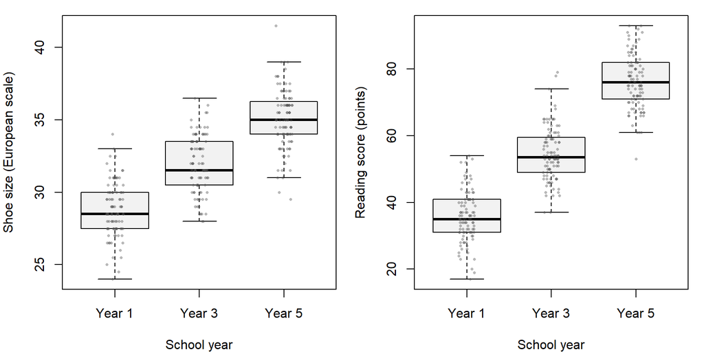

Distribution summaries and individual observations within each school year.

```r
local({
  old <- par(mfrow = c(1, 2), mar = c(4, 4, 1, 1))
  on.exit(par(old))
  set.seed(808) # Jitter changes only horizontal display positions.
  boxplot(shoe_size ~ school_year, dat, outline = FALSE, col = "grey95",
          xlab = "School year", ylab = "Shoe size (European scale)",
          ylim = range(dat$shoe_size))
  stripchart(shoe_size ~ school_year, dat, method = "jitter", add = TRUE,
             vertical = TRUE, pch = 16, cex = 0.5,
             col = adjustcolor("grey30", alpha.f = 0.4))
  boxplot(reading_score ~ school_year, dat, outline = FALSE, col = "grey95",
          xlab = "School year", ylab = "Reading score (points)",
          ylim = range(dat$reading_score))
  stripchart(reading_score ~ school_year, dat, method = "jitter", add = TRUE,
             vertical = TRUE, pch = 16, cex = 0.5,
             col = adjustcolor("grey30", alpha.f = 0.4))
})
```

## 3.3 The pooled association

```r
pooled_fit <- lm(reading_score ~ shoe_size, data = dat)
pooled_r <- cor(dat$shoe_size, dat$reading_score)
pooled_slope <- unname(coef(pooled_fit)[2])
pooled_r
```

```
## [1] 0.720209
```

```r
coef(pooled_fit)
```

```
## (Intercept)   shoe_size
##  -77.162698    4.151867
```

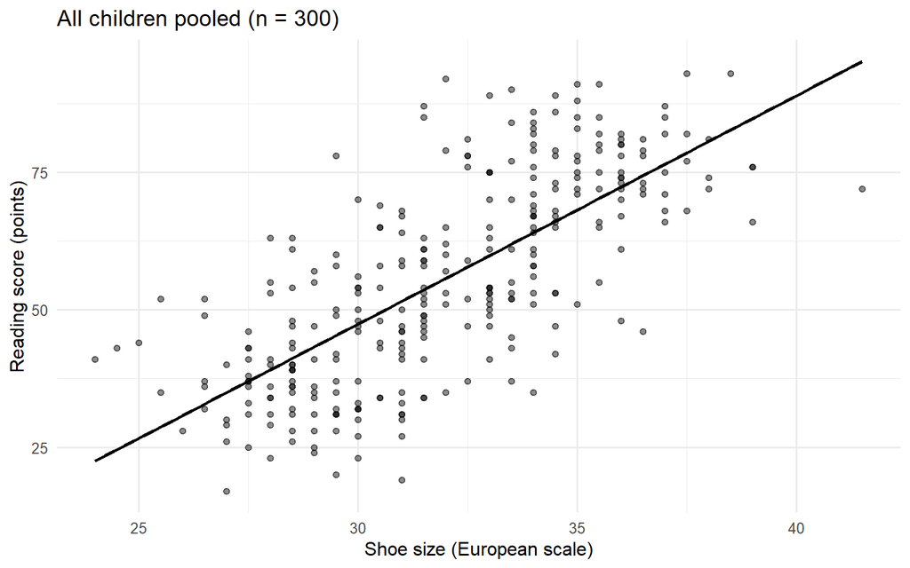

Ignoring school year gives a clear positive linear association.

```r
pooled_plot <- ggplot(dat, aes(shoe_size, reading_score)) +
  geom_point(alpha = 0.45) +
  geom_smooth(method = "lm", formula = y ~ x, se = FALSE,
              colour = "black", linewidth = 0.9) +
  labs(x = "Shoe size (European scale)", y = "Reading score (points)",
       title = "All children pooled (n = 300)")
pooled_plot
```

The pooled correlation is **0.720**. The slope is **4.15 reading-score points per shoe-size unit**. This is a strong positive association across the pooled children. It does not show that larger shoes improve reading or describe the change that would follow from increasing an individual child’s shoe size. The intercept at shoe size zero has no useful interpretation here.

## 3.4 Within-year associations

```r
fits <- lapply(by_year, function(d) lm(reading_score ~ shoe_size, data = d))
association <- function(d, label) {
  fit <- lm(reading_score ~ shoe_size, data = d)
  data.frame(Group = label, n = nrow(d),
             Correlation = cor(d$shoe_size, d$reading_score),
             Slope = unname(coef(fit)[2]))
}
comparison <- do.call(rbind, c(
  list(association(dat, "All children")),
  lapply(year_levels, function(g) association(by_year[[g]], g))
))
knitr::kable(comparison, digits = 3, row.names = FALSE,
             caption = "Slopes are reading-score points per shoe-size unit.")
```

Slopes are reading-score points per shoe-size unit.

| Group | n | Correlation | Slope |
| --- | --- | --- | --- |
| All children | 300 | 0.720 | 4.152 |
| Year 1 | 100 | -0.120 | -0.487 |
| Year 3 | 100 | 0.056 | 0.235 |
| Year 5 | 100 | 0.051 | 0.198 |

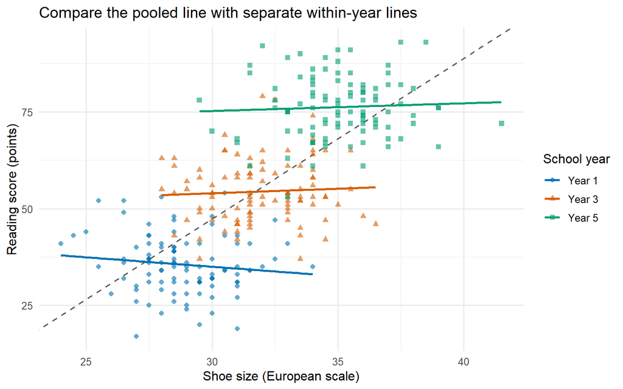

The dashed pooled line spans differences between years; solid lines describe separate within-year fits.

```r
grouped_plot <- ggplot(dat, aes(shoe_size, reading_score)) +
  geom_abline(intercept = coef(pooled_fit)[1], slope = pooled_slope,
              linetype = "dashed", colour = "grey35") +
  geom_point(aes(colour = school_year, shape = school_year),
             alpha = 0.6, size = 1.8) +
  geom_smooth(aes(colour = school_year), method = "lm", formula = y ~ x,
              se = FALSE, fullrange = FALSE, linewidth = 0.9) +
  scale_colour_manual(values = year_colours, name = "School year") +
  scale_shape_manual(values = year_shapes, name = "School year") +
  labs(x = "Shoe size (European scale)", y = "Reading score (points)",
       title = "Compare the pooled line with separate within-year lines")
grouped_plot
```

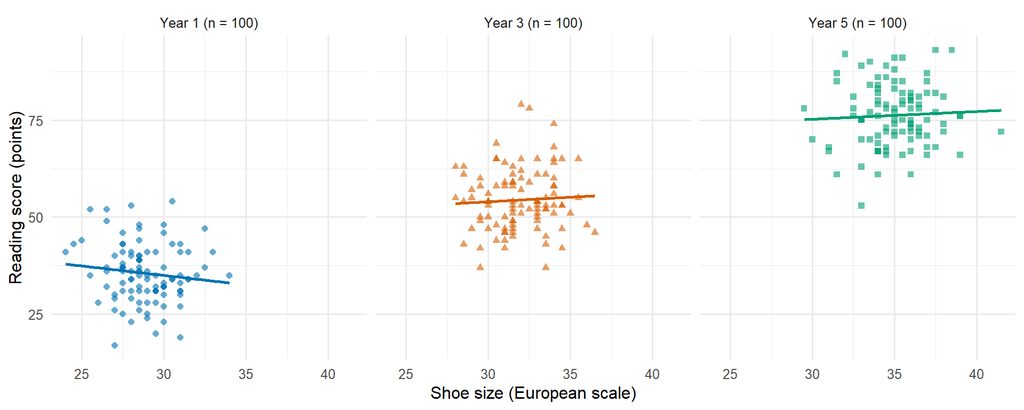

All panels share axis limits. Fitted lines stop at each year’s observed shoe-size range.

```r
panel_labels <- setNames(paste0(year_levels, " (n = 100)"), year_levels)
faceted_plot <- ggplot(dat, aes(shoe_size, reading_score)) +
  geom_point(aes(colour = school_year, shape = school_year),
             alpha = 0.6, size = 1.7) +
  geom_smooth(aes(colour = school_year), method = "lm", formula = y ~ x,
              se = FALSE, fullrange = FALSE, linewidth = 0.9) +
  facet_wrap(~ school_year, scales = "fixed",
             labeller = as_labeller(panel_labels)) +
  scale_colour_manual(values = year_colours) +
  scale_shape_manual(values = year_shapes) +
  coord_cartesian(xlim = range(dat$shoe_size),
                  ylim = range(dat$reading_score)) +
  labs(x = "Shoe size (European scale)", y = "Reading score (points)") +
  theme(legend.position = "none")
faceted_plot
```

Within-year correlations range from **-0.120** to **0.056**. The slopes are small compared with the pooled slope, and the panels show no clear linear trend. The strong pooled association therefore disappears as a substantial linear relationship when we compare children within years. The estimated within-year correlations are close to zero, not exactly zero.

School year separates groups with different typical shoe sizes and reading scores. The pooled line connects these groups; it does not represent their internal relationships. A near-zero Pearson correlation alone does not rule out a nonlinear relationship or prove independence. Here the plots agree with the weak within-year linear associations.

## 3.5 Compare the other categorical variables

The handout asks students to explore these variables before revealing the within-year contrast. This worked solution places the comparisons together so their different roles are easy to assess.

### 3.5.1 Category composition across school years

```r
balance_tables <- lapply(other_categories, function(v) {
  counts <- table(dat$school_year, dat[[v]])
  proportions <- prop.table(counts, margin = 1)
  # Exact equality across school years, not a non-significant test result.
  stopifnot(all(apply(proportions, 2, function(p) max(p) - min(p)) == 0))
  data.frame(
    Variable = v, Category = colnames(counts),
    Total_n = as.integer(colSums(counts)),
    Year_1_percent = 100 * proportions["Year 1", ],
    Year_3_percent = 100 * proportions["Year 3", ],
    Year_5_percent = 100 * proportions["Year 5", ], row.names = NULL
  )
})
balance <- do.call(rbind, balance_tables)
knitr::kable(balance, digits = 0, row.names = FALSE,
             caption = "Category percentages within each school year.")
```

Category percentages within each school year.

| Variable | Category | Total_n | Year_1_percent | Year_3_percent | Year_5_percent |
| --- | --- | --- | --- | --- | --- |
| handedness | Left | 30 | 10 | 10 | 10 |
| handedness | Right | 270 | 90 | 90 | 90 |
| favourite_colour | Blue | 75 | 25 | 25 | 25 |
| favourite_colour | Green | 75 | 25 | 25 | 25 |
| favourite_colour | Red | 75 | 25 | 25 | 25 |
| favourite_colour | Yellow | 75 | 25 | 25 | 25 |
| birth_season | Winter | 75 | 25 | 25 | 25 |
| birth_season | Spring | 75 | 25 | 25 | 25 |
| birth_season | Summer | 75 | 25 | 25 | 25 |
| birth_season | Autumn | 75 | 25 | 25 | 25 |

Every year has 10% left-handed and 90% right-handed children, 25% in each favourite-colour category, and 25% in each birth-season category. Thus each additional variable is exactly independent of school year in this dataset. This balance was imposed for teaching; a real survey would rarely have such identical proportions. Independence from school year alone does not prove that a variable is unrelated to either measurement, so inspect those too.

### 3.5.2 Measurements and associations within each category

```r
category_results <- do.call(rbind, lapply(other_categories, function(v) {
  do.call(rbind, lapply(levels(dat[[v]]), function(label) {
    d <- dat[dat[[v]] == label, ]
    result <- association(d, label)
    data.frame(Variable = v, Category = result$Group, n = result$n,
               Mean_shoe = mean(d$shoe_size),
               Mean_reading = mean(d$reading_score),
               Correlation = result$Correlation, Slope = result$Slope)
  }))
}))
knitr::kable(category_results, digits = 3, row.names = FALSE)
```

| Variable | Category | n | Mean_shoe | Mean_reading | Correlation | Slope |
| --- | --- | --- | --- | --- | --- | --- |
| handedness | Left | 30 | 31.533 | 56.500 | 0.714 | 4.445 |
| handedness | Right | 270 | 31.976 | 55.293 | 0.723 | 4.137 |
| favourite_colour | Blue | 75 | 31.820 | 54.853 | 0.704 | 3.870 |
| favourite_colour | Green | 75 | 32.153 | 55.467 | 0.771 | 4.919 |
| favourite_colour | Red | 75 | 31.727 | 56.373 | 0.702 | 3.744 |
| favourite_colour | Yellow | 75 | 32.027 | 54.960 | 0.717 | 4.246 |
| birth_season | Winter | 75 | 31.893 | 56.053 | 0.694 | 3.993 |
| birth_season | Spring | 75 | 31.780 | 55.773 | 0.717 | 3.989 |
| birth_season | Summer | 75 | 31.947 | 54.773 | 0.697 | 4.142 |
| birth_season | Autumn | 75 | 32.107 | 55.053 | 0.777 | 4.520 |

The shoe-size/reading correlations within these categories range from **0.694** to **0.777**. The strong positive relationship remains. Each category still mixes children from all three school years, in the same proportions as the full dataset. Splitting by these variables therefore leaves the between-year explanation in place. By contrast, splitting by school year removes that mixture and reveals the weak within-year associations.

Small differences in category means arise from the random assignments. The additional categories were assigned independently of both quantitative draws; the mechanism contains no effect of handedness, favourite colour, or birth season on either measurement. This is a simulation assumption, not a claim that these characteristics are irrelevant in real children.

```r
comparison_plot <- function(variable) {
  plot_data <- dat
  plot_data$Category <- plot_data[[variable]]
  ggplot(plot_data, aes(shoe_size, reading_score)) +
    geom_point(aes(colour = school_year, shape = school_year),
               alpha = 0.55, size = 1.6) +
    geom_smooth(method = "lm", formula = y ~ x, se = FALSE,
                fullrange = FALSE, colour = "black", linewidth = 0.8) +
    facet_wrap(~ Category, nrow = 1, scales = "fixed") +
    scale_colour_manual(values = year_colours, name = "School year") +
    scale_shape_manual(values = year_shapes, name = "School year") +
    coord_cartesian(xlim = range(dat$shoe_size),
                    ylim = range(dat$reading_score)) +
    labs(x = "Shoe size (European scale)", y = "Reading score (points)") +
    theme(legend.position = "bottom")
}
comparison_plots <- setNames(lapply(other_categories, comparison_plot),
                            other_categories)
```

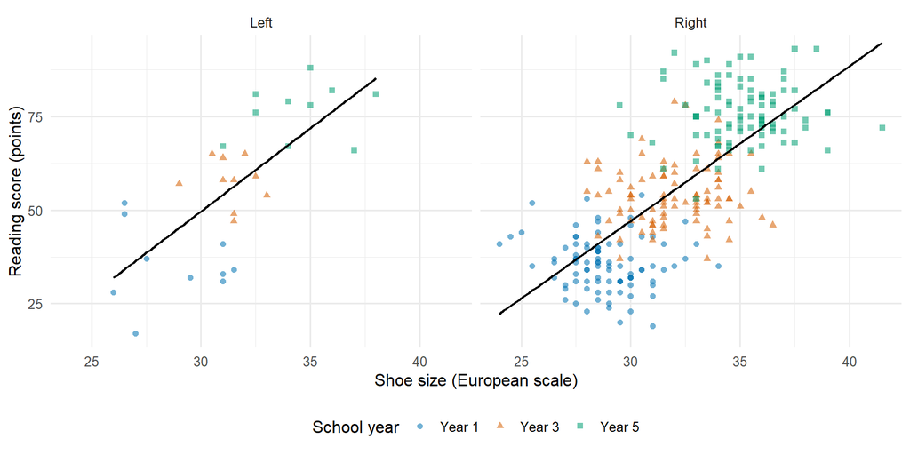

Grouping by handedness retains the mixture of school years and the positive association.

```r
comparison_plots$handedness
```

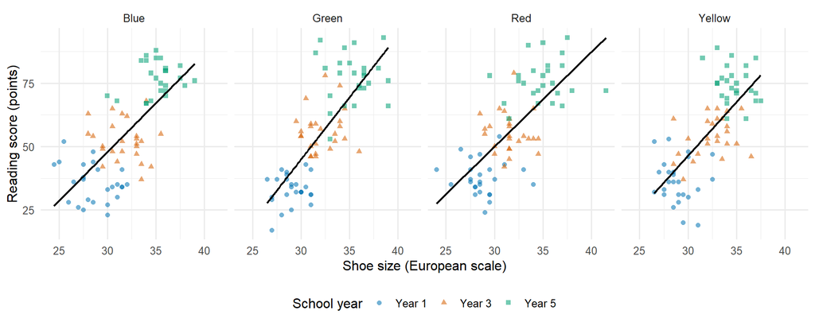

Favourite-colour panels all retain the positive association. Colours and symbols of the points identify school year.

```r
comparison_plots$favourite_colour
```

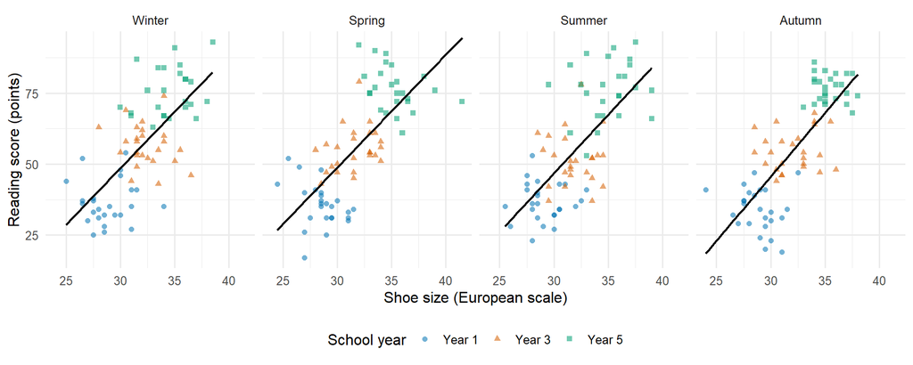

Birth-season panels also retain the positive association, with common axes.

```r
comparison_plots$birth_season
```

The left-handed group contains 30 children, compared with 270 in the right-handed group; the other categories contain 75 each. Smaller groups give less stable summaries. Splitting simultaneously by school year and several other variables can create very small cells, so it is not required. These comparisons do not justify a rule that a variable is a confounder only if adjustment reduces a correlation. A study explanation and the relationships among variables matter as well.

## 3.6 Verify one calculation independently

```r
d <- by_year[["Year 1"]]
dx <- d$shoe_size - mean(d$shoe_size)
dy <- d$reading_score - mean(d$reading_score)
manual_r <- sum(dx * dy) / sqrt(sum(dx^2) * sum(dy^2))
manual_slope <- sum(dx * dy) / sum(dx^2)
stopifnot(
  isTRUE(all.equal(manual_r, comparison$Correlation[2])),
  isTRUE(all.equal(manual_slope, comparison$Slope[2]))
)
data.frame(Year = "Year 1", Correlation = manual_r, Slope = manual_slope)
```

```
##     Year Correlation      Slope
## 1 Year 1  -0.1197279 -0.4870063
```

```r
# Checks of the intended teaching contrast, not significance tests:
stopifnot(pooled_r > 0.65,
          all(abs(comparison$Correlation[-1]) < 0.15),
          all(abs(comparison$Slope[-1]) < 0.6),
          all(category_results$Correlation > 0.6))
```

# 4 Explain the result and revise the design

In the simplified teaching model, school year shifts both measurements:

- School year → typical shoe size.
- School year → typical reading score.
- No arrow from shoe size to reading score is used to generate the data.

In real children, school year reflects maturation and time in education; the administrative label itself does not cause feet to grow. Stratifying by year makes children more comparable but cannot guarantee that all developmental or social differences have been removed.

A suitable final conclusion is:

> Children with larger shoe sizes tend to score higher when all years are pooled. Within each school year, shoe size has little linear association with reading score. Differences between school years account for the strong pooled pattern in this simulated dataset. These observations do not support a claim that increasing shoe size would improve reading.

Revise the study to recruit adequate numbers within each planned year, use comparable measurements, and report within-year results alongside pooled results. State the target population and recruitment limitations. A pooled predictive relationship can also fail when the mixture of school years changes. Further background variables should be chosen from a plausible study explanation rather than by searching for factors that erase a result.

Common issues to discuss in feedback:

| Issue | Useful correction |
| --- | --- |
| Only a pooled correlation is reported | Add within-year correlations, slopes, and plots. |
| Every recorded category is called a confounder | Compare year composition and measurements, and give a plausible study explanation. |
| School year is entered as 1, 3, 5 in a regression | Use categories and separate simple regressions for this activity. |
| Every panel has different axes | Use common axes to make slope and spread comparisons meaningful. |
| A small correlation is called exactly zero | Describe its magnitude; do not claim proven independence. |
| A p-value above 0.05 is called proof of no effect | Discuss effect sizes and scatterplots; this exercise does not require tests. |
| The example is called a sign reversal | The main contrast is disappearance of the pooled trend, not a consistent reversal. |
| A new simulation is substituted for the CSV | Analyse the shared fixed dataset so group results are comparable. |

# 5 Instructor notes: data choice and simulation

## 5.1 Real data considered first

A targeted search did not identify a verified, simple real dataset of two quantitative measurements whose strong association vanishes within all categories of a suitable confounder. This is a limited search, not a claim that no such data exist.

Two accessible real-data candidates were checked:

- [UC Berkeley admissions, R datasets documentation](https://stat.ethz.ch/R-manual/R-devel/library/datasets/html/UCBAdmissions.html): real admissions counts classified by recorded sex and department. This is useful for categorical association, but it does not provide two quantitative variables for the planned scatterplots and simple regressions.
- [Iris measurements, R datasets documentation](https://stat.ethz.ch/R-manual/R-devel/library/datasets/html/iris.html): real quantitative measurements with species as a categorical grouping variable. For the natural petal-length/petal-width example, positive associations remain within species, so it does not give the requested disappearance. The calculation below documents that check.

```r
iris_check <- rbind(
  data.frame(Group = "All species",
             Correlation = cor(iris$Petal.Length, iris$Petal.Width)),
  do.call(rbind, lapply(split(iris, iris$Species), function(d)
    data.frame(Group = as.character(d$Species[1]),
               Correlation = cor(d$Petal.Length, d$Petal.Width))))
)
knitr::kable(iris_check, digits = 3, row.names = FALSE)
```

| Group | Correlation |
| --- | --- |
| All species | 0.963 |
| setosa | 0.332 |
| versicolor | 0.787 |
| virginica | 0.322 |

The shoe-size/reading example is therefore simulated and explicitly labelled throughout. Its numerical values are chosen for an understandable classroom contrast; they are not estimates of real children’s development or validated reading norms.

## 5.2 Generating mechanism and reproducibility

The instructor script `data/08_generate_shoe_size_reading.R` uses seed 804, 100 children in each year, and independent normal draws within each year:

| School year | Mean shoe size | Shoe-size SD | Mean reading score | Reading-score SD |
| --- | --- | --- | --- | --- |
| Year 1 | 29 | 1.8 | 35 | 7 |
| Year 3 | 32 | 1.8 | 55 | 7 |
| Year 5 | 35 | 1.8 | 75 | 7 |

Shoe sizes are rounded to the nearest half unit and scores to integers. The script checks that all resulting scores are within 0–100; it does not clip, remove, or redraw observations. Random draws of the two measurements are independent within each year, including after separate rounding. Sampling variation gives the small nonzero observed correlations.

After generating the quantitative measurements, seed 805 assigns the three additional categorical variables by random permutations within each school year: 90 Right and 10 Left labels, 25 labels of each favourite colour, and 25 labels of each birth season. Assignments use no shoe sizes or reading scores. Each variable is exactly balanced across years; neither exact balance between the additional variables nor exactly equal measurement means across their categories is imposed. The original child identifiers, shoe sizes, reading scores, and school years are unchanged.

To regenerate the CSV deliberately, run the following from `didactic_materials`. It overwrites the shared CSV, so this code is **not evaluated when knitting this solution**.

```r
source("data/08_generate_shoe_size_reading.R")
```

The supplied CSV should be used for teaching even if a future R version or random-number configuration produces different draws. It is the common reference for students and this solution.

> **Note on AI assistance**

> These teaching materials were prepared with assistance from ChatGPT (OpenAI) in drafting explanations, developing examples, and generating R code. The author retains responsibility for the final content.